# Probabilidad

Fecha: *2021-12-12*  
Autor: *Carlos Enrique Lopez Cervantes*  
Bibliografia: Introducción a la Probabilidad - Luis Rincón

### **¿Que estudia la Probabilidad?**

La probabilidad es la parte de las matemáticas que se encarga del estudio de los fenómenos o experimentos aleatorios. Por experimento aleatorio entenderemos todo aquel experimento que cuando se le repite bajo las mismas condiciones iniciales, el resultado que se obtiene no siempre es el mismo. Por ejemplo, ¿Cual es la probabilidad de obtener el valor 5 en la cara superior al lanzar un dado?

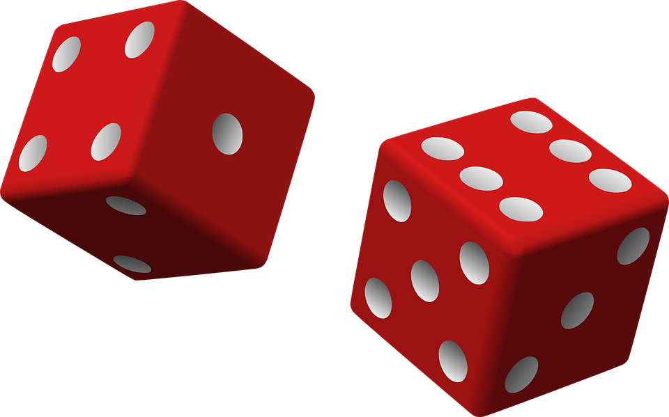

### **Espacio muestral**

El espacio muestral (o también llamado espacio muestra) de un experimento aleatorio es el conjunto de todos los posibles resultados del experimento, y se le denota generalmente por la letra griega **Ω (omega)**. Si retomamos el ejemplo del lanzamiento de un dado, al lanzar el dado, el espacio muestral es el conjunto Ω = {1, 2, 3, 4, 5, 6}, es decir, todos los posibles resultados que podemos obtener.

### **Evento**

Llamamos eventos a los subconjuntos del espacio muestral a los cuales podemos asignarles ciertos números, llamados probabilidades, que tratan de medir la incertidumbre de que un resultado de un experimento aleatorio pertenezca a dicho conjunto de resultados. Aunque en cursos más rigurosos de probabilidad resulta que en general no es lo mismo un evento que un subconjunto del espacio muestral, en este curso nos limitaremos a espacios muestrales en los cuales todos los subconjuntos sí serán eventos. Por ejemplo, un evento puede ser *A = Obtener un número impar al lanzar un dado*.

### **Conjuntos**

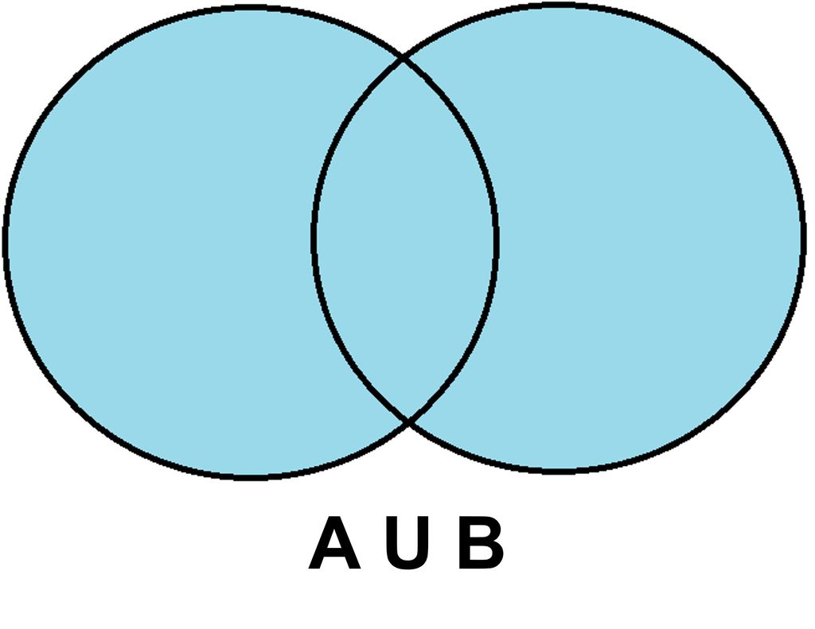

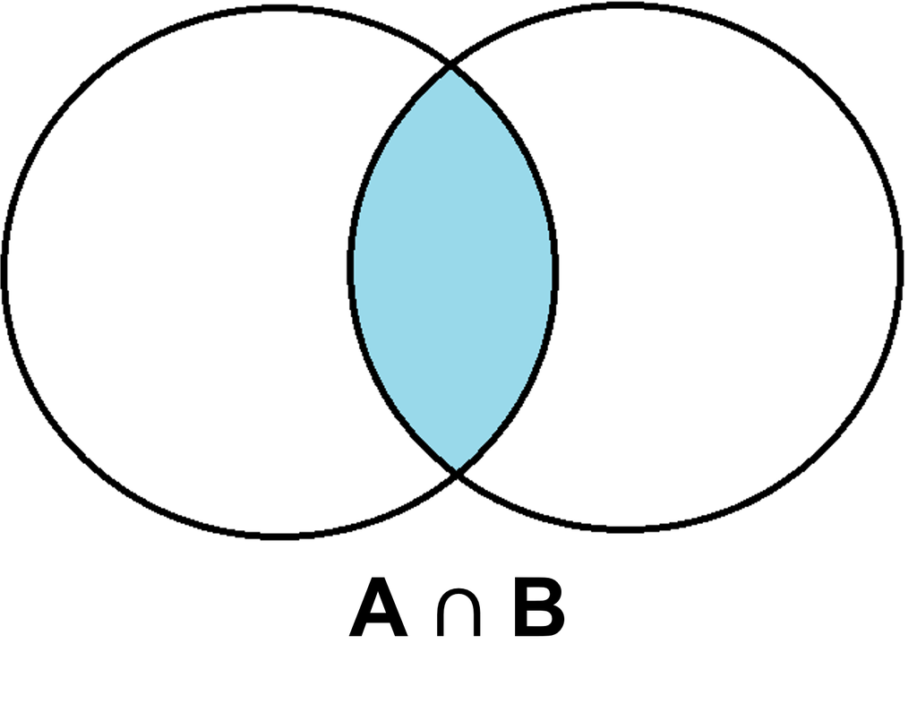

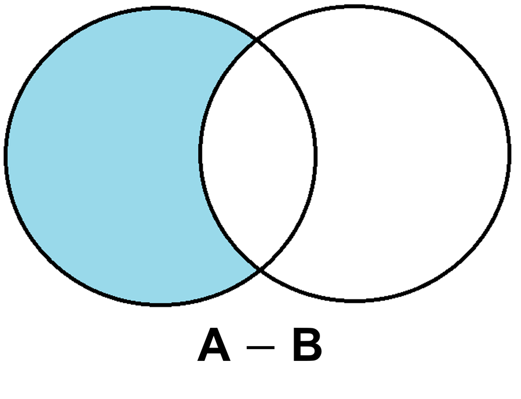

### **Probabilidad**

La probabilidad de un evento A, es un número real en el intervalo [0, 1] que denotaremos por **P(A)**, y representa una medida de la frecuencia con la que se observa la ocurrencia del evento A cuando se puede repetir una y otra vez el experimento aleatorio en cuestión. Esta es la interpretación frecuentista de la probabilidad.

Desde el punto de vista clásico, la probabilidad P de que suceda un evento A de un total de n casos posibles igualmente probables es igual a:

P(A) = $\frac{Casos \ favorables}{Casos \ totales}$

### **Variable Aleatoria**

Dado un experimento aleatorio cualquiera, una variable aleatoria es una transformación X del espacio de resultados Ω al conjunto de números reales, esto es, X : Ω → R.

A menudo se escribe simplemente v.a. en lugar del término variable aleatoria. En sentido estricto una variable aleatoria es una función de **Ω** en **R (los reales)** que satisface además cierta condición de medibilidad, pero omitiremos tales tecnicismos pues no son de utilidad para los propósitos de este curso. Suponga entonces que se efectúa el experimento aleatorio una vez y se obtiene un resultado ω en Ω. Al transformar este resultado con la variable aleatoria X se obtiene un número real X(ω) = x. Podemos entonces suponer que los posibles resultados del experimento aleatorio son los diferentes números reales x que la función X puede tomar.

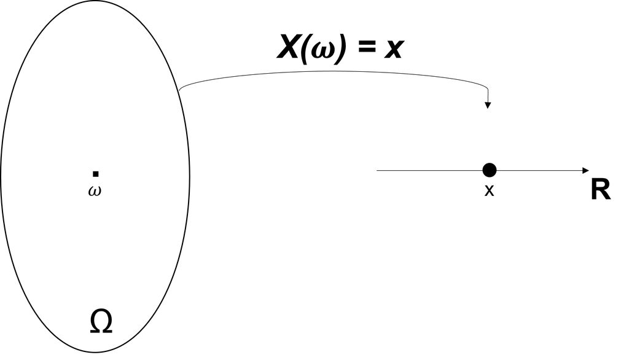

Considerando el conjunto de valores que una variable aleatoria puede tomar, vamos a clasificar a las variables aleatorias en dos tipos: **discretas o continuas**.

**Variable aleatoria Discreta:** Decimos que una v.a. es discreta cuando el conjunto de valores que ésta toma es un conjunto discreto, es decir, un conjunto finito o numerable.

**Variable aleatoria Continua:** Decimos que una variable aleatoria es continua cuando toma todos los valores dentro de un intervalo (a, b) ⊆ R.

### **Funciones de densidad y de distribución**

La funciones de densidad y de distribución nos permiten representar a un mismo tiempo tanto los valores que puede tomar la variable como las probabilidades de los distintos eventos.

**Funcion de probabilidad para una variable discreta**: Sea X una variable aleatoria discreta que toma los valores x1, x2, etc… con probabilidades respectivas P(X = x1), P(X = x2), etc…. Esta lista de valores numéricos y sus probabilidades puede ser finita o bien infinita, pero numerable. La función de probabilidad de la variable X denotada por f(x) : R → [0, ∞) se define como sigue:

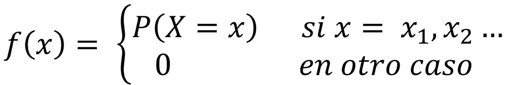

En palabras, la función de probabilidad es simplemente aquella función que indica los valores de la probabilidad en los distintos valores que toma la variable aleatoria discreta.

Observe que se cumplen las siguientes dos propiedades:

1. f(x) ≥ 0, para toda x ∈ R.

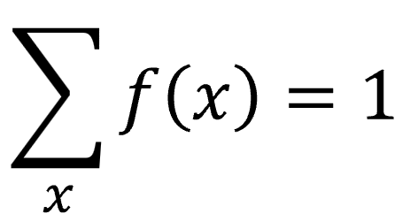

**Funcion de densidad para una variable continua**: Sea X una variable aleatoria continua. Decimos que la función integrable y no negativa f(x) : R → [0, ∞) es la función de densidad de X si para cualquier intervalo (a, b) de R se cumple la igualdad:

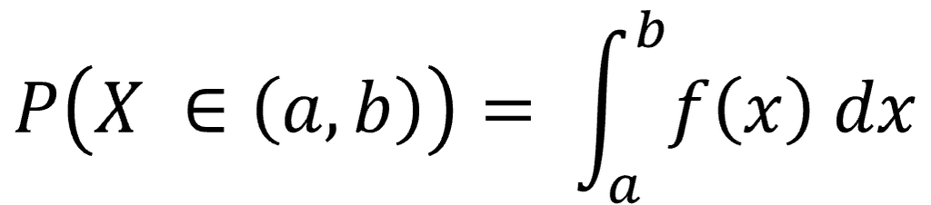

Es decir, la probabilidad de que la variable tome un valor dentro del intervalo (a, b) se puede calcular o expresar como el área bajo la función de densidad en el intervalo (a, b).

Toda función de densidad f(x) de una variable aleatoria continua cumple las siguientes propiedades análogas al caso discreto.

1. f(x) ≥ 0, para toda x ∈ R.

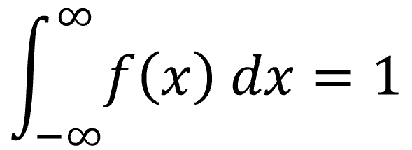

Toda función f(x) : R → [0, ∞) que satisfaga estas dos propiedades, sin necesidad de tener una variable aleatoria de por medio, se llamará función de densidad.

**Funcion de distribución.** Sea X una variable aleatoria discreta o continua. La función de distribución de X, denotada por F(x) : R → [0, 1], se define como F(x) = P(X ≤ x). Esto es, la función de distribución evaluada en un número x cualquiera es simplemente la probabilidad de que la variable aleatoria tome un valor menor o igual a x. Siendo F(x) una probabilidad, sus valores están siempre entre 0 y 1. Esta función resulta ser importante y se le conoce también, por razones evidentes, con el nombre de *función de distribución de probabilidad acumulada*.

### **Distribuciones de probabilidad**

#### **Distribución Binomial**

Una distribución binomial es una distribución de probabilidad discreta que describe el número de éxitos al realizar n experimentos independientes entre sí, acerca de una variable aleatoria.

Existen una gran diversidad de experimentos o sucesos que pueden ser caracterizados bajo esta distribución de probabilidad. Imaginemos el lanzamiento de una moneda en el que definimos el suceso “sacar cara” como el éxito. Si lanzamos 5 veces la moneda y contamos los éxitos (sacar cara) que obtenemos, nuestra distribución de probabilidades se ajustaría a una distribución binomial.

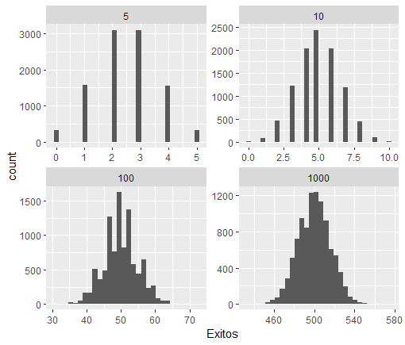

#### **Distribución Normal**

Esta es posiblemente la distribución de probabilidad de mayor importancia. Decimos que la variable aleatoria continua X tiene una distribución normal si su función de densidad está dada por la siguiente expresión:

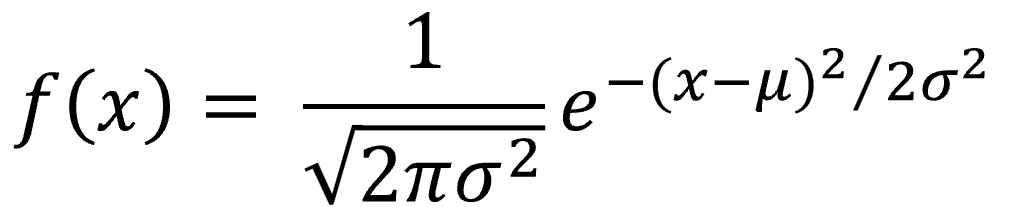

en donde µ ∈ R y σ > 0 son dos parámetros. Escribimos entonces $X ∼ N(µ, σ^2)$. La gráfica de esta función de densidad tiene forma de campana como se puede apreciar en la siguiente gráfica:

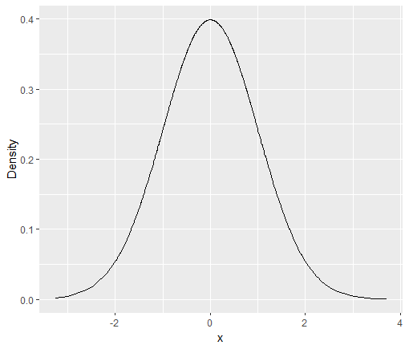

El Coeficiente Intelectual (IQ) de un grupo de personas es un fenómeno que se puede modelar con una distribución Normal.